# Multivariate Analysis

# 1장. 다변량 데이터 알아보기

## 예제1

### Loading data

```r
A.Data <- read.table("/Users/jaeyonglee/Documents/College/Bachelor/uniwise/MVA/R/data/ch1/A_Data.txt", header=TRUE, sep="\t", skip=3)
A.Data
```

| X1 | X2 |
| --- | --- |
| 90 | 80 |
| 80 | 90 |
| 75 | 80 |
| 70 | 70 |
| 65 | 80 |

### 표본평균벡터

```r
mu <- c(mean(A.Data$X1), mean(A.Data$X2))
mu
```

```
[1] 76 80
```

### 표본공분산행렬

```r
S <- cov(A.Data)
S
```

```
     X1 X2
X1 92.5 25
X2 25.0 50
```

### 표본상관행렬

```r
R <- cor(A.Data)
R
```

```
          X1        X2
X1 1.0000000 0.3676073
X2 0.3676073 1.0000000
```

### 1번과 2번 obs.의 유클리드 거리

```r
de <- dist(A.Data[1:2,], method="euclidean")
de
```

```
         1
2 14.14214
```

```r
# 직접 수식으로 구하기
de <- (as.matrix(A.Data[1,]-A.Data[2,])) %*% t(as.matrix(A.Data[1,]-A.Data[2,]))
# A.Data는 리스트라 as.matrix로 해주고, %%는 행렬 연산할 때 사용, t는 전치를 해줌
de <- sqrt(de)
de
```

```
         1
1 14.14214
```

### 1번과 2번 obs.의 표준화 거리

```r
# S는 위에서 구한 표본공분산행렬
D <- diag(diag(S))  # 표본공분산행렬의 대각원소만 추출하고 그걸 대각행렬로 인식
ds <- (as.matrix(A.Data[1,]-A.Data[2,])) %*% solve(D) %*% t(as.matrix(A.Data[1,]-A.Data[2,]))
# solve()는 역행열을 구해줌
ds <- sqrt(ds)
ds
```

```
         1
1 1.755301
```

### 1번과 2번 obs.의 마할라노비스 거리

```r
dm <- (as.matrix(A.Data[1,]-A.Data[2,])) %*% solve(S) %*% t(as.matrix(A.Data[1,]-A.Data[2,]))
dm <- sqrt(dm)
dm
```

```
         1
1 2.193741
```

## 예제2

### Loading data

```r
tree <- read.csv("/Users/jaeyonglee/Documents/College/Bachelor/uniwise/MVA/R/data/ch1/Tree.csv", header=TRUE)
tree
```

| Tree | N | E | S | W |
| --- | --- | --- | --- | --- |
| 1 | 72 | 66 | 76 | 77 |
| 2 | 60 | 53 | 66 | 63 |
| 3 | 56 | 57 | 64 | 58 |
| 4 | 41 | 29 | 36 | 38 |
| 5 | 32 | 32 | 35 | 36 |
| 6 | 30 | 35 | 34 | 26 |
| 7 | 39 | 39 | 31 | 27 |
| 8 | 42 | 43 | 31 | 25 |
| 9 | 37 | 40 | 31 | 25 |
| 10 | 33 | 29 | 27 | 36 |

[output cut: 18 more lines]

### 표본평균벡터

```r
m <- colMeans(tree[,-1])  #[,-1]인 이유는 Tree column은 단순 인덱스이기 때문
m
```

```
       N        E        S        W
50.53571 46.17857 49.67857 45.21429
```

### 표본공분산행렬

```r
CS <- cov(tree[,-1])
CS
```

```
         N        E        S        W
N 290.4061 223.7526 288.4378 225.5847
E 223.7526 219.9299 229.0595 170.7751
S 288.4378 229.0595 350.0040 258.9603
W 225.5847 170.7751 258.9603 224.7672
```

### 표본상관행렬

```r
CR <- cor(tree[,-1])
CR
```

```
          N         E         S         W
N 1.0000000 0.8853667 0.9047173 0.8829584
E 0.8853667 1.0000000 0.8256001 0.7680969
S 0.9047173 0.8256001 1.0000000 0.9232733
W 0.8829584 0.7680969 0.9232733 1.0000000
```

각각 동서남북 간의 관계가 큰 것을 볼 수 있다.

### 산점도 행렬

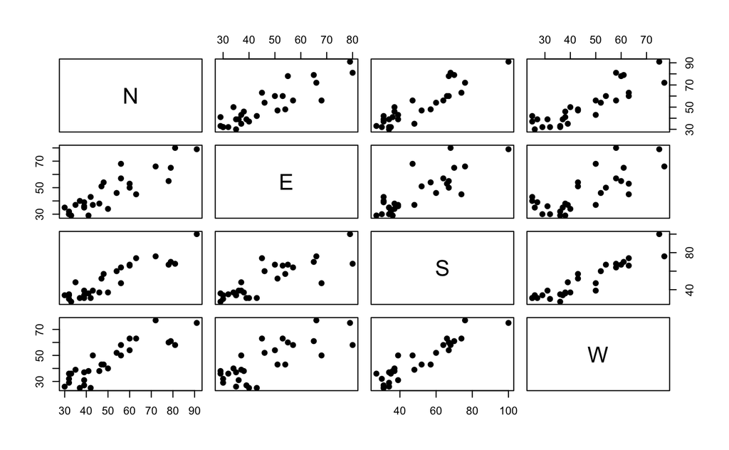

```r
plot(tree[,-1], pch=19)
```

#### 동서남북 모두 양의 선형관계가 있는 것을 볼 수 있다.

### 3D 산점도

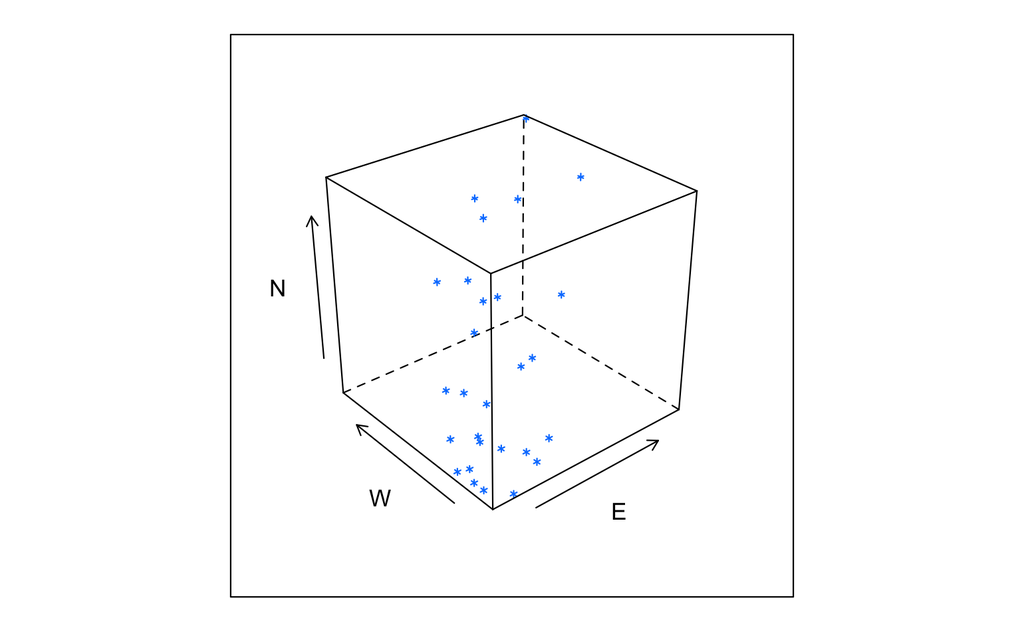

```r
library(lattice)  # 평행그림, 3D 산점도 패키지

cloud(N ~ E*W, data=tree)  # 순서대로 Z축 ~ X축*Y축 이다
```

### Trellis 그래프 (Parallel 그래프)

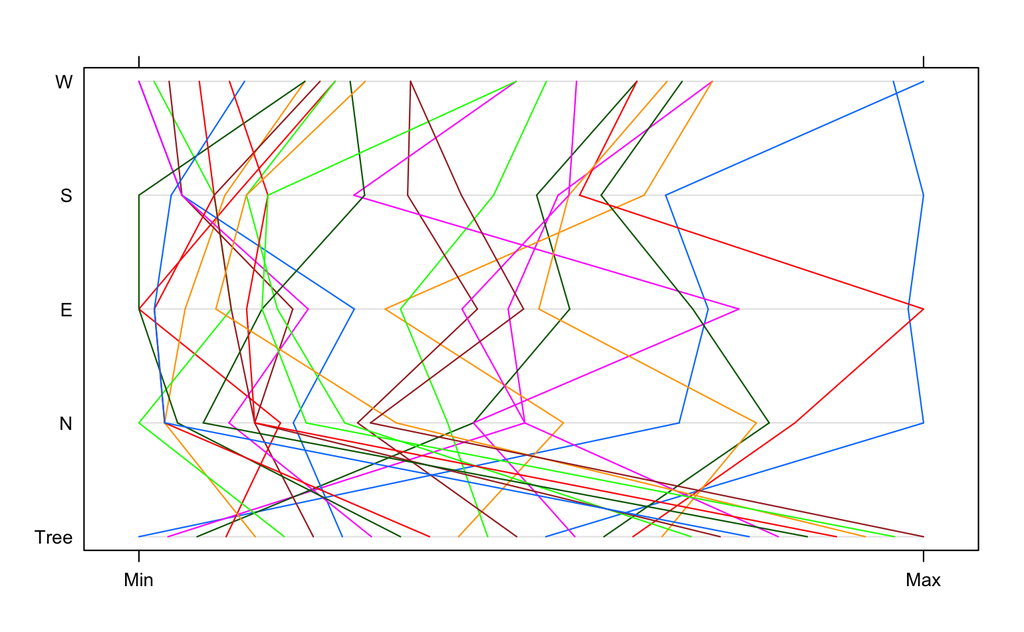

```r
library(lattice)

parallelplot(tree)
```

#### 근데 이 그래프는 이해하기가 힘들다는 단점이 있다.

### 별그림

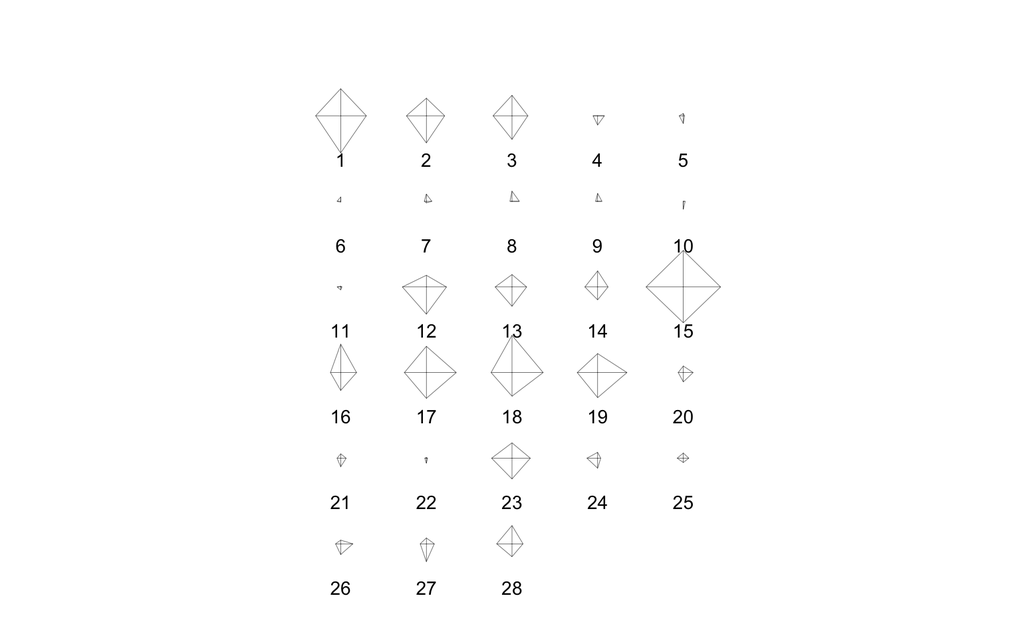

```r
stars(tree[,-1], labels=tree[,1])
```

#### 번호별로 어떤 것들이 비슷한지 쉽게 볼 수 있다.

### 체르노프 얼굴그림

```
effect of variables:
 modified item       Var
 "height of face   " "N"
 "width of face    " "E"
 "structure of face" "S"
 "height of mouth  " "W"
 "width of mouth   " "N"
 "smiling          " "E"
 "height of eyes   " "S"
 "width of eyes    " "W"
 "height of hair   " "N"
 "width of hair   "  "E"
 "style of hair   "  "S"
 "height of nose  "  "W"
 "width of nose   "  "N"
 "width of ear    "  "E"
 "height of ear   "  "S"
```

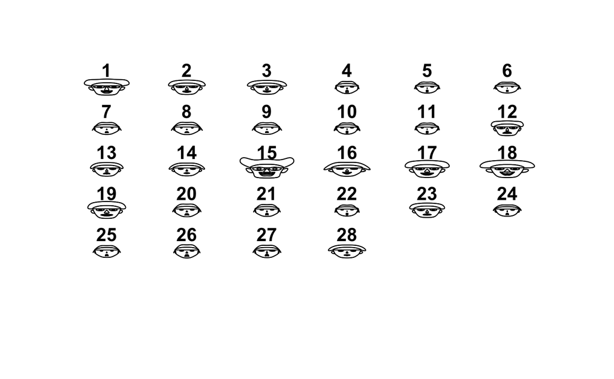

```r
# install.packages("aplpack")
library(aplpack)

faces(tree[,-1], ncolors=0)
```

# 2장. 기초 행렬 대수

## 행렬의 정의

### 2X3 행렬

```r
A <- matrix(c(3, -1, 2, 1, 5, 4), ncol=3, byrow=TRUE)  # nrow 또는 ncol로 만들어주자
A
```

```
     [,1] [,2] [,3]
[1,]    3   -1    2
[2,]    1    5    4
```

### 전치행렬

```r
tA <- t(A)
tA
```

```
     [,1] [,2]
[1,]    3    1
[2,]   -1    5
[3,]    2    4
```

## 행렬의 연산

### 두 벡터: a, b

```r
a <- c(1,-2,3)
a
```

```
[1]  1 -2  3
```

```r
b <- c(2,2,4)
b
```

```
[1] 2 2 4
```

### 벡터의 합: a+b

```r
a + b
```

```
[1] 3 0 7
```

### 벡터의 곱: a’b

```r
t(a) %*% b
```

```
     [,1]
[1,]   10
```

### 벡터의 스칼라배: ca

```r
3*a
```

```
[1]  3 -6  9
```

### 벡터의 길이

```r
La <- sqrt(t(a) %*% a)
La
```

```
         [,1]
[1,] 3.741657
```

```r
Lb <- sqrt(t(b) %*% b)
Lb
```

```
         [,1]
[1,] 4.898979
```

### 두 벡터 사이의 각

```r
cos.theta <- (t(a) %*% b)/(La*Lb)  # cos theta
cos.theta
```

```
          [,1]
[1,] 0.5455447
```

```r
acos(cos.theta)*180/pi  # acos() 값은 radian값, 180/pi를 곱해주면 degree값임
```

```
        [,1]
[1,] 56.9381
```

### 두 행렬: A, B

```r
A <- matrix(c(3,1,-1,5,2,4), ncol=3)
A
```

```
     [,1] [,2] [,3]
[1,]    3   -1    2
[2,]    1    5    4
```

```r
B <- matrix(c(1,-1,2,3,3,5), ncol=3)
B
```

```
     [,1] [,2] [,3]
[1,]    1    2    3
[2,]   -1    3    5
```

### 두 행렬의 합: A+B

```r
A+B
```

```
     [,1] [,2] [,3]
[1,]    4    1    5
[2,]    0    8    9
```

### 행렬의 스칼라배: cA

```r
3*A
```

```
     [,1] [,2] [,3]
[1,]    9   -3    6
[2,]    3   15   12
```

### 전치행렬: B’

```r
t(B)
```

```
     [,1] [,2]
[1,]    1   -1
[2,]    2    3
[3,]    3    5
```

### 행렬의 곱: A’B, AB’

```r
t(A) %*% B
```

```
     [,1] [,2] [,3]
[1,]    2    9   14
[2,]   -6   13   22
[3,]   -2   16   26
```

```r
A %*% t(B)
```

```
     [,1] [,2]
[1,]    7    4
[2,]   23   34
```

### 행렬의 행렬식

```r
A <- matrix(c(1,-3,2,5), ncol=2)
A
```

```
     [,1] [,2]
[1,]    1    2
[2,]   -3    5
```

```r
det(A)  # det()로 쉽게 구할 수 있다
```

```
[1] 11
```

```r
A <- matrix(c(1,0,1,2,3,5,1,4,6), ncol=3)  #  ncol로 행렬 모양을 결정지을 때,
                                           # 원소 값을 줄 때 열벡터를 넣듯이 넣어라
A
```

```
     [,1] [,2] [,3]
[1,]    1    2    1
[2,]    0    3    4
[3,]    1    5    6
```

```r
det(A)
```

```
[1] 3
```

### 행렬의 역행렬

```r
A <- matrix(c(1,-3,2,5), ncol=2)
A
```

```
     [,1] [,2]
[1,]    1    2
[2,]   -3    5
```

```r
solve(A)  # solve()로 역행렬을 구할 수 있다; 'MASS' package의 ginv()로도 구할 수 있다.
```

```
          [,1]        [,2]
[1,] 0.4545455 -0.18181818
[2,] 0.2727273  0.09090909
```

#### 맞는지 확인은 항등행렬이 도출 되는지로 알 수 있다.

```r
A %*% solve(A)
```

```
     [,1]         [,2]
[1,]    1 2.775558e-17
[2,]    0 1.000000e+00
```

#### 근데 완전히 1이 아닐 수도 있나봄?

```r
A <- matrix(c(1,0,1,2,3,5,1,4,6), ncol=3)
A
```

```
     [,1] [,2] [,3]
[1,]    1    2    1
[2,]    0    3    4
[3,]    1    5    6
```

```r
solve(A)
```

```
           [,1]      [,2]      [,3]
[1,] -0.6666667 -2.333333  1.666667
[2,]  1.3333333  1.666667 -1.333333
[3,] -1.0000000 -1.000000  1.000000
```

#### 맞는지 확인

```r
A %*% solve(A)
```

```
     [,1] [,2] [,3]
[1,]    1    0    0
[2,]    0    1    0
[3,]    0    0    1
```

### 트레이스

```r
A <- matrix(c(3,-sqrt(2),-sqrt(2),2), ncol=2)
A
```

```
          [,1]      [,2]
[1,]  3.000000 -1.414214
[2,] -1.414214  2.000000
```

```r
diag(A)  # diag()가 대각원소만 추출
```

```
[1] 3 2
```

```r
sum(diag(A))
```

```
[1] 5
```

### 직교행렬

```r
a <- sqrt(2)
A <- matrix(c(1/a, -1/a, 1/a, 1/a), ncol=2)
A
```

```
           [,1]      [,2]
[1,]  0.7071068 0.7071068
[2,] -0.7071068 0.7071068
```

```r
t(A) %*% A
```

```
     [,1] [,2]
[1,]    1    0
[2,]    0    1
```

A’A = I

```r
A %*% t(A)
```

```
     [,1] [,2]
[1,]    1    0
[2,]    0    1
```

AA’ = I

```r
t(A)
```

```
          [,1]       [,2]
[1,] 0.7071068 -0.7071068
[2,] 0.7071068  0.7071068
```

```r
solve(A)
```

```
          [,1]       [,2]
[1,] 0.7071068 -0.7071068
[2,] 0.7071068  0.7071068
```

A’ = A^-1

```r
tht = 60/180*pi  # 60도
A <- matrix(c(cos(tht),sin(tht),-sin(tht),cos(tht)), ncol=2)
A
```

```
          [,1]       [,2]
[1,] 0.5000000 -0.8660254
[2,] 0.8660254  0.5000000
```

```r
t(A) %*% A
```

```
     [,1] [,2]
[1,]    1    0
[2,]    0    1
```

A’A = I

```r
A %*% t(A)
```

```
     [,1] [,2]
[1,]    1    0
[2,]    0    1
```

AA’ = I

```r
t(A)
```

```
           [,1]      [,2]
[1,]  0.5000000 0.8660254
[2,] -0.8660254 0.5000000
```

```r
solve(A)
```

```
           [,1]      [,2]
[1,]  0.5000000 0.8660254
[2,] -0.8660254 0.5000000
```

#### A’ = A^-1

### 고유값과 고유벡터

```r
A <- matrix(c(4, 2, -5, -3), ncol=2)
A
```

```
     [,1] [,2]
[1,]    4   -5
[2,]    2   -3
```

```r
EG <- eigen(A)  # eigen()이 고유값과 단위고유벡터 둘다 구해준다
EG
```

```
eigen() decomposition
$values
[1]  2 -1

$vectors
          [,1]      [,2]
[1,] 0.9284767 0.7071068
[2,] 0.3713907 0.7071068
```

#### values가 고유값(순서대로 람다1, 람다2), vectors가 단위고유벡터(1열이 e1, 2열이 e2)

### 고유값의 성질

```r
sum(diag(A))
```

```
[1] 1
```

```r
sum(EG$values)
```

```
[1] 1
```

tr(A)는 고유값들의 합과 같다

```r
det(A)
```

```
[1] -2
```

```r
EG$values[1]*EG$values[2]  # prod()로 sum()처럼 원소들의 곲을 구할 수도 있음
```

```
[1] -2
```

det(A)는 고유값들의 곲과 같다

```r
A <- matrix(c(3, 1, 1, 3), ncol = 2)
A
```

```
     [,1] [,2]
[1,]    3    1
[2,]    1    3
```

```r
EG <- eigen(A)
EG
```

```
eigen() decomposition
$values
[1] 4 2

$vectors
          [,1]       [,2]
[1,] 0.7071068 -0.7071068
[2,] 0.7071068  0.7071068
```

```r
sum(diag(A))
```

```
[1] 6
```

```r
sum(EG$values)
```

```
[1] 6
```

#### tr(A)은 고유값들의 합과 같다

```r
det(A)
```

```
[1] 8
```

```r
prod(EG$values)
```

```
[1] 8
```

#### det(A)는 고유값들의 곲과 같다

### 스펙트럼 분해

```r
A <- matrix(c(3,1,1,3), ncol=2)
A
```

```
     [,1] [,2]
[1,]    3    1
[2,]    1    3
```

```r
EG <- eigen(A)
EG
```

```
eigen() decomposition
$values
[1] 4 2

$vectors
          [,1]       [,2]
[1,] 0.7071068 -0.7071068
[2,] 0.7071068  0.7071068
```

```r
P <- EG$vectors  # 단위고유벡터 직교행렬 P
P
```

```
          [,1]       [,2]
[1,] 0.7071068 -0.7071068
[2,] 0.7071068  0.7071068
```

```r
lambda <- diag(EG$values)  # 고유값 대각행렬 람다
lambda
```

```
     [,1] [,2]
[1,]    4    0
[2,]    0    2
```

```r
P %*% lambda %*% t(P)
```

```
     [,1] [,2]
[1,]    3    1
[2,]    1    3
```

#### A = P lambda P’

```r
t(P) %*% A %*% P
```

```
     [,1] [,2]
[1,]    4    0
[2,]    0    2
```

# 3장. 다변량 확률표본에 대한 기초

```r
A.Data <- read.table("/Users/jaeyonglee/Documents/College/Bachelor/uniwise/MVA/R/data/ch3/A_Data.txt", header=TRUE, sep="\t", skip=3)
A.Data
```

| X1 | X2 |
| --- | --- |
| 90 | 80 |
| 80 | 90 |
| 75 | 80 |
| 70 | 70 |
| 65 | 80 |

```r
p <- dim(A.Data)[2]  # 변수 개수
p
```

```
[1] 2
```

### 표본공분산행렬

```r
S <- cov(A.Data)
S
```

```
     X1 X2
X1 92.5 25
X2 25.0 50
```

### 표본상관행렬

```r
R <- cor(A.Data)
R
```

```
          X1        X2
X1 1.0000000 0.3676073
X2 0.3676073 1.0000000
```

### 일반화표본분산

```r
det(S)
```

```
[1] 4000
```

### 총표본분산

```r
sum(diag(S))
```

```
[1] 142.5
```

### 행렬 R(표본상관행렬)의 고유값

```r
EG <- eigen(R)

lambda <- EG$values
lambda
```

```
[1] 1.3676073 0.6323927
```

#### 순서대로 람다1, 람다2

### 변수들 상호상관

```r
# 조건수
inter.corr1 <- lambda[1]/lambda[2]
inter.corr1
```

```
[1] 2.162592
```

```r
# Hoerl, Kennard
inter.corr2 <- 1/lambda[1] + 1/lambda[2]
inter.corr2
```

```
[1] 2.3125
```

```r
# Rencher Pun
inter.corr3 <- (1/p)*(1/lambda[1] + 1/lambda[2])
inter.corr3
```

```
[1] 1.15625
```

```r
# Heo - g1
inter.corr4 <- (1-lambda[2]/lambda[1])^(p+2)
inter.corr4
```

```
[1] 0.08352392
```

```r
# g2
inter.corr5 <- 1-(p/(1/lambda[1] + 1/lambda[2]))
inter.corr5
```

```
[1] 0.1351351
```

```r
# g3
inter.corr6 <- 1-sqrt(det(R))
inter.corr6
```

```
[1] 0.07001889
```

```r
# g4
inter.corr7 <- (lambda[1]/p)^(3/2)
inter.corr7
```

```
[1] 0.5654538
```

```r
# g5
inter.corr8 <- (1-lambda[2]/p)^5
inter.corr8
```

```
[1] 0.1495055
```

# 4장. 다변량 정규분포

## 이변량 정규분포

```r
mu1 <- 0  # X1의 모평균
mu2 <- 0  # X2의 모평균

s11 <- 1  # X1의 모분산
s22 <- 1  # X2의 모분산
s12 <- 0.5  # X1과 X2의 공분산
rho <- 0.5  # X1과 X2의 상관계수

x1 <- seq(-3.1, 3.1, length=51)  # 확률변수 X1의 값
x2 <- x1  # 확률변수 X2의 값
```

### 이변량 정규분포의 확률밀도함수

```r
f <- function(x1, x2){  # 확률밀도함수를 직접 구현
  term1 = 1/(2*pi*sqrt(s11*s22*(1-rho^2)))
  term2 = -1/(2*(1-rho^2))
  term3 = (x1-mu1)^2/s11
  term4 = (x2-mu2)^2/s22
  term5 = 2*rho*(((x1-mu1)/sqrt(s11))*((x2-mu2)/sqrt(s22)))

  term1*exp(term2*(term3+term4-term5))
}

z = outer(x1,x2,f)  # outer()로 x1과 x2의 조합을 가지고 f함수에 대입해 값을 도출
```

```r
length(z)  # 길이가 51인 두 변수들의 조합으로 구한 값이므로 51*51개의 z값을 갖는 것임
```

```
[1] 2601
```

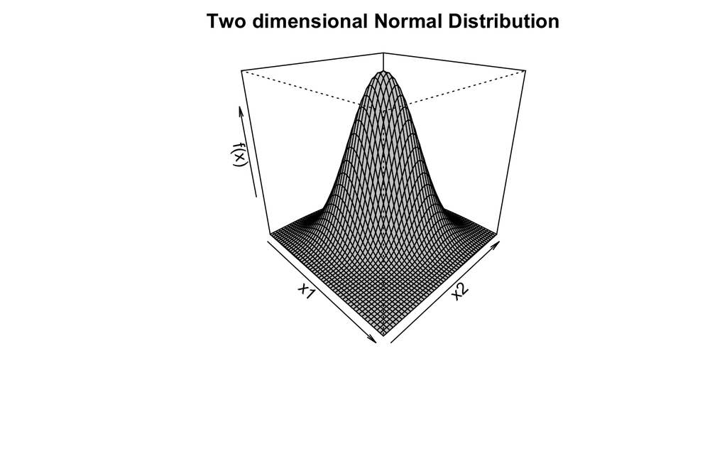

```r
persp(x1,x2,z, main="Two dimensional Normal Distribution",
      theta=45, phi=25, col=gray(.8), zlab="f(x)")  # theta랑 phi는 그래프의 기울기, 각도? 조정
```

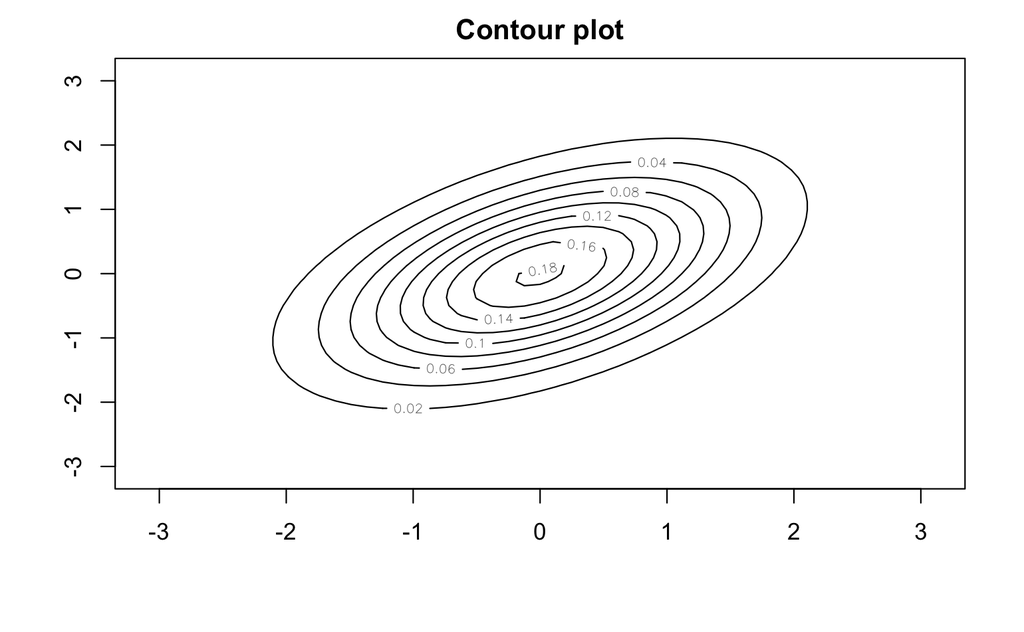

```r
contour(x1,x2,z, main="Contour plot")  # 등고선도
```

안쪽의 값이 더 큰 것을 볼 수 있다. (가운데 쪽이 봉우리에 해당). 참고로 z의 최대값이 0.18임

# 4장-2. 일변량 변수에 대한 정규성 평가

## Normal Q-Q plot을 이용한 정규성 평가

#### Loading data

```r
A.Area <- read.csv("/Users/jaeyonglee/Documents/College/Bachelor/uniwise/MVA/R/data/ch4/A_Area.txt", header=TRUE, skip=3)
attach(A.Area)
A.Area
```

| Age | Income |
| --- | --- |
| 68 | 4 |
| 58 | 45 |
| 45 | 35 |
| 50 | 25 |
| 33 | 28 |
| 24 | 11 |
| 58 | 10 |
| 22 | 9 |
| 47 | 20 |
| 30 | 35 |

### 변수별 평균

```r
m <- apply(A.Area, MARGIN=2, FUN=mean)  # MARGIN=1이면 행, 2이면 열을 기준으로, FUN은 함수
m
```

```
   Age Income
  43.5   22.2
```

### 공분산 행렬

```r
S <- cov(A.Area)
S
```

```
               Age      Income
Age    245.8333333   0.6666667
Income   0.6666667 185.9555556
```

### 표본수

```r
n <- length(Age)
n
```

```
[1] 10
```

### 순서

```r
i <- 1:n
i
```

```
 [1]  1  2  3  4  5  6  7  8  9 10
```

### Age 순서통계량

```r
Age.S <- sort(Age)
Age.S
```

```
 [1] 22 24 30 33 45 47 50 58 58 68
```

### Income 순서통계량

```r
Income.S <- sort(Income)
Income.S
```

```
 [1]  4  9 10 11 20 25 28 35 35 45
```

### 경험적 분포

```r
edf <- (i-0.5)/n
edf
```

```
 [1] 0.05 0.15 0.25 0.35 0.45 0.55 0.65 0.75 0.85 0.95
```

### 표준정규분포 분위수

```r
q <- qnorm(edf, mean=0, sd=1)
q
```

```
 [1] -1.6448536 -1.0364334 -0.6744898 -0.3853205 -0.1256613  0.1256613  0.3853205  0.6744898
 [9]  1.0364334  1.6448536
```

### Age 순서통계량과 정규분포 사분위수와 normal Q-Q plot

```r
AgeQ.Table <- cbind(i, Age.S, edf,q)
AgeQ.Table
```

```
       i Age.S  edf          q
 [1,]  1    22 0.05 -1.6448536
 [2,]  2    24 0.15 -1.0364334
 [3,]  3    30 0.25 -0.6744898
 [4,]  4    33 0.35 -0.3853205
 [5,]  5    45 0.45 -0.1256613
 [6,]  6    47 0.55  0.1256613
 [7,]  7    50 0.65  0.3853205
 [8,]  8    58 0.75  0.6744898
 [9,]  9    58 0.85  1.0364334
[10,] 10    68 0.95  1.6448536
```

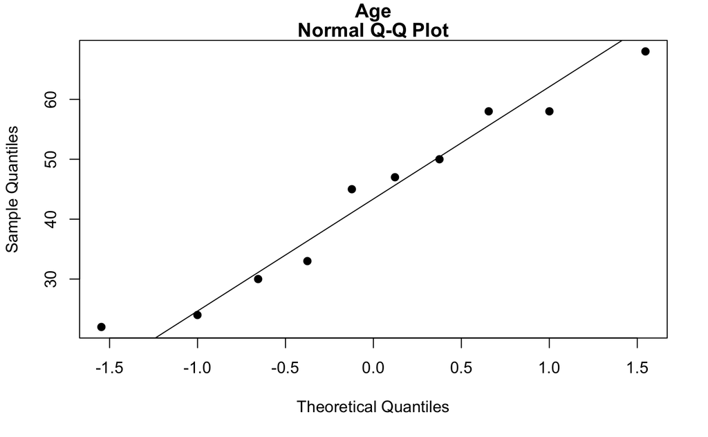

```r
qqnorm(Age, pch=19, main=c("Age", "Normal Q-Q Plot"))
qqline(Age)  # Age normal Q-Q line
```

#### 점들이 직선에서 크게 벗어나지 않은 것을 보면, 순서통계량과 표준정규분포의 분위수간의 선형성을 크게 벗어나지 않음을 볼 수 있어 정규성을 벗어나지 않음

### Income 순서통계량과 정규분포 사분위수와 normal Q-Q plot

```r
IncomeQ.Table <- cbind(i, Income.S, edf,q)
IncomeQ.Table
```

```
       i Income.S  edf          q
 [1,]  1        4 0.05 -1.6448536
 [2,]  2        9 0.15 -1.0364334
 [3,]  3       10 0.25 -0.6744898
 [4,]  4       11 0.35 -0.3853205
 [5,]  5       20 0.45 -0.1256613
 [6,]  6       25 0.55  0.1256613
 [7,]  7       28 0.65  0.3853205
 [8,]  8       35 0.75  0.6744898
 [9,]  9       35 0.85  1.0364334
[10,] 10       45 0.95  1.6448536
```

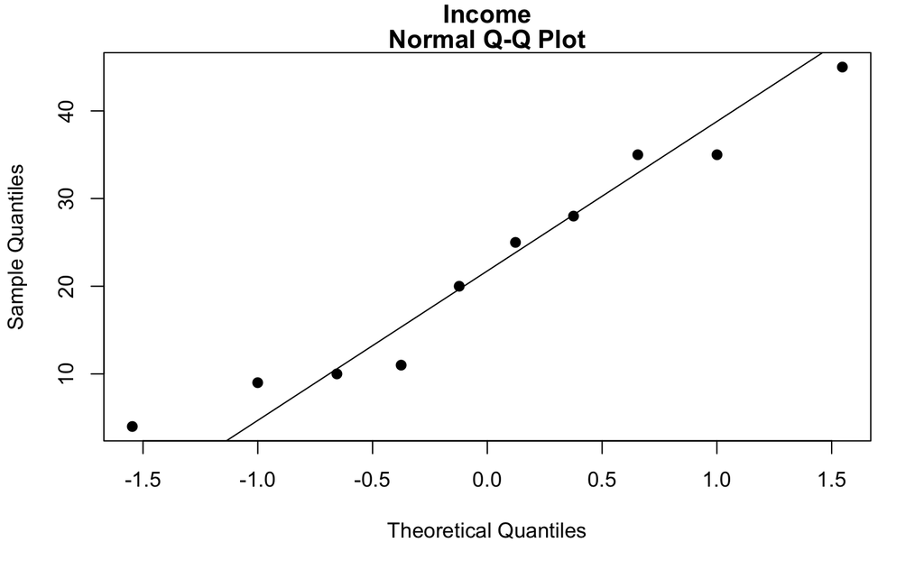

```r
qqnorm(Income, pch=19, main=c("Income", "Normal Q-Q Plot"))
qqline(Income)  # Income normal Q-Q line; 변수가 실제로 정규분포일때 얻을 직선을 그려줌
```

#### 점들이 직선에서 크게 벗어나지 않은 것을 보면, 순서통계량과 표준정규분포의 분위수간의 선형성을 크게 벗어나지 않음을 볼 수 있어 정규성을 벗어나지 않음

## Pearson 상관계수와 가설검정을 이용한 정규성 평가

#### (위 데이터와 동일한 데이터를 사용)

### Age 순서통계량과 정규분포 분위수의 상관계수

#### Age 순서통계량과 정규분포 분위수의 공분산행렬을 구하고

```r
AgeQ.S <- cov(AgeQ.Table[,c(2,4)])  # [,c(2,4)] 로 테이블에서 Age.S 와 q만을 사용
AgeQ.S
```

```
          Age.S          q
Age.S 245.83333 15.1766095
q      15.17661  0.9775415
```

#### 상관계수 공식을 이용

```r
AgeQ.S[1,2]/sqrt(AgeQ.S[1,1]*AgeQ.S[2,2])
```

```
[1] 0.9790092
```

#### 상관행렬을 이용해서 상관계수를 바로 구할 수도 있음

```r
cor(AgeQ.Table[,c(2,4)])
```

```
          Age.S         q
Age.S 1.0000000 0.9790092
q     0.9790092 1.0000000
```

```r
cor(AgeQ.Table[,c(2,4)])[1,2]
```

```
[1] 0.9790092
```

### Income 순서통계량과 정규분포 분위수의 상관계수

```r
cor(AgeQ.Table[,c(2,4)])
```

```
          Age.S         q
Age.S 1.0000000 0.9790092
q     0.9790092 1.0000000
```

```r
cor(IncomeQ.Table[,c(2,4)])[1,2]
```

```
[1] 0.9759712
```

### 가설

#### H0: 정규성이 성립한다

#### H1: 정규성이 성립하지 않는다

#### 각 변수의 순서통계량과 정규분포 분위수의 상관계수를 가지고, ‘Q-Q 그림 상관계수를 이용한 정규성 검정 주요 기각값’ 표에서 유의수준과 표본수(n)에 따라 기각값을 구해 가설검정을 하면 된다. 여기서, 상관계수가 기각값보다 큰 경우 귀무가설을 채택하게 된다.

#### 가설을 기각하지 못하는 경우, 해당 변수는 정규분포를 따른다고 할 수 있다.

#### 상관계수를 이용한 정규성 평가가 Q-Q plot보다 더 객관적이라는 장점이 있다.

# 4장-3. 다변량 변수벡터에 대한 정규성 평가 - 예제1

## Chisquare plot for multivariate normality

#### Loading data

```r
A.Area <- read.csv("/Users/jaeyonglee/Documents/College/Bachelor/uniwise/MVA/R/data/ch4/A_Area.txt", header=TRUE, skip=3)
attach(A.Area)
A.Area
```

| Age | Income |
| --- | --- |
| 68 | 4 |
| 58 | 45 |
| 45 | 35 |
| 50 | 25 |
| 33 | 28 |
| 24 | 11 |
| 58 | 10 |
| 22 | 9 |
| 47 | 20 |
| 30 | 35 |

### 표본의 수

```r
n <- dim(A.Area)[1]
n
```

```
[1] 10
```

### 변수의 수 (= 카이제곱의 자유도)

```r
p <- dim(A.Area)[2]
p
```

```
[1] 2
```

### 평균벡터

```r
m <- colMeans(A.Area)
m
```

```
   Age Income
  43.5   22.2
```

### 공분산행렬

```r
S <- cov(A.Area)
S
```

```
               Age      Income
Age    245.8333333   0.6666667
Income   0.6666667 185.9555556
```

### 공분산행렬의 역행렬

```r
solve(S)
```

```
                 Age        Income
Age     4.067836e-03 -1.458354e-05
Income -1.458354e-05  5.377681e-03
```

### 마할라노비스 거리의 순서통계량

```r
d2 <- mahalanobis(A.Area, m, S)  # 마할라노비스 거리
d2.S <- sort(d2)  # 순서통계량
d2.S
```

```
 [1] 0.07608356 0.21349626 0.63116041 0.88967194 1.62748252 1.66083630 2.21500096 2.80908684
 [9] 3.64115379 4.23602743
```

### 순서

```r
i <- 1:n
i
```

```
 [1]  1  2  3  4  5  6  7  8  9 10
```

### 경험적 분포

```r
edf <- (i-0.5)/n
edf
```

```
 [1] 0.05 0.15 0.25 0.35 0.45 0.55 0.65 0.75 0.85 0.95
```

### 카이제곱(df=2)의 분위수

```r
q <- qchisq(edf, p)
q
```

```
 [1] 0.1025866 0.3250379 0.5753641 0.8615658 1.1956740 1.5970154 2.0996442 2.7725887
 [9] 3.7942400 5.9914645
```

### 마할라노비스 거리 순서통계량과 카이제곱(df=2)분포 분위수와 Chisquare plot

```r
cbind(i, d2.S, edf,q)
```

```
       i       d2.S  edf         q
 [1,]  1 0.07608356 0.05 0.1025866
 [2,]  2 0.21349626 0.15 0.3250379
 [3,]  3 0.63116041 0.25 0.5753641
 [4,]  4 0.88967194 0.35 0.8615658
 [5,]  5 1.62748252 0.45 1.1956740
 [6,]  6 1.66083630 0.55 1.5970154
 [7,]  7 2.21500096 0.65 2.0996442
 [8,]  8 2.80908684 0.75 2.7725887
 [9,]  9 3.64115379 0.85 3.7942400
[10,] 10 4.23602743 0.95 5.9914645
```

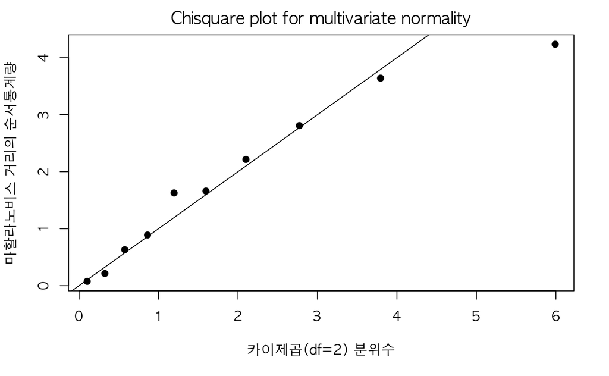

```r
par(family="AppleGothic")
plot(q, d2.S, pch=19, main="Chisquare plot for multivariate normality", xlab="카이제곱(df=2) 분위수", ylab="마할라노비스 거리의 순서통계량")   # 이렇게 산점도를 그리는 방식으로 그리는 듯
abline(0,1)  # 절편이 0이고 기울기가 1
```

#### 이상치가 하나 보이긴 하나(선형성을 크게 벗어나는 점은 이상점으로 볼 수 있는지에 대한 점검이 필요), 전반적으로 정규성을 따르는 것으로 보임.

## 다변량 왜도와 첨도를 이용한 정규성 검정

#### (위와 같은 데이터)

### 공분산행렬 최우추정량(MLE)

```r
S <- cov(A.Area)  # 표본공분산행렬
S <- (n-1)/n*S
S
```

```
          Age Income
Age    221.25   0.60
Income   0.60 167.36
```

### 공분산행렬 최우추정량의 역행렬

```r
solve(S)
```

```
                 Age        Income
Age     4.519818e-03 -1.620394e-05
Income -1.620394e-05  5.975201e-03
```

### 다변량 왜도와 첨도의 추정값 구하기

```r
sk <- function(x){
  n <- dim(x)[1]  # 표본의 수
  p <- dim(x)[2]  # 변수의 수

  m <- colMeans(x)  # 평균벡터

  S <- cov(x)  # 표본공분산행렬
  S <- (n-1)/n*S  # 공분산행렬 최우추정량(MLE)
  S.inv <- solve(S)  # 공분산행렬 최우추정량의 역행렬

  g <- matrix(rep(NA,n*n), ncol=n)  # g행렬 선언
  # g행렬 구하기
  for(i in 1:n){
    for(j in 1:n){
      g[i,j] <- t(x[i,]-m) %*% S.inv %*% (x[j,]-m)
    }
  }

  b1 <- sum(g^3)/n^2  # 왜도
  b2 <- sum(diag(g)^2)/n  # 첨도

  result <- c(b1, b2)
  names(result) <- c("왜도", "첨도")
  return(result)
}
```

#### g행렬 구할 때 행렬연산이 있으므로 데이터를 행렬로 변환시키고 구하자

```r
mat <- as.matrix(A.Area)  # 데이터 타입을 matrix로

sk(mat)
```

```
    왜도     첨도
1.411685 6.252772
```

### 가설

#### H0: 정규성이 성립한다 (왜도 = 0 and 첨도 = p(p+2); 둘다 만족되어야 함)

#### H1: 정규성이 성립하지 않는다

#### 각 변수의 순서통계량과 정규분포 분위수의 상관계수를 가지고, ‘왜도에 대한 상위백분위수, 첨도에 대한 상위,하위 백분위수’ 표에서 유의수준, 표본수(n), 변수의 수(p)에 따라 기각값을 구해 가설검정을 하면 된다. 이때 추정값이 기각값보다 큰 경우 귀무가설을 기각하게 된다. 즉, 두 추정값 모두 기각값보다 작아야 귀무가설을 채택하게 된다.

#### p > 5, n > 50인 경우에는, 왜도와 첨도에 카이제곱 검정을 따로 해서 정규성 검정을 하게 된다. (노트 참고)

#### 가설을 기각하지 못하는 경우, 해당 변수는 정규분포를 따른다고 할 수 있다.

#### 다변량 첨도와 왜도를 이용한 정규성 평가가 Chiosquare plot보다 더 객관적이라는 장점이 있다.

# 4장-3. 다변량 변수벡터에 대한 정규성 평가 - 예제2

#### 4개의 각 변수가 일변량 정규분포를 따르는지를 정규확률그림을 통하여 검토하고 4개 변수가 4변량 정규분포를 따르는지 카이제곱그림을 그려 알아보자.

#### Loading data

```r
tree <- read.csv("/Users/jaeyonglee/Documents/College/Bachelor/uniwise/MVA/R/data/ch4/Tree.csv", header=TRUE)
cork <- tree[,-1]  # 이 데이터셋의 첫번째 변수(1열)는 단순 인덱스이므로 빼주자
attach(cork)
cork
```

| N | E | S | W |
| --- | --- | --- | --- |
| 72 | 66 | 76 | 77 |
| 60 | 53 | 66 | 63 |
| 56 | 57 | 64 | 58 |
| 41 | 29 | 36 | 38 |
| 32 | 32 | 35 | 36 |
| 30 | 35 | 34 | 26 |
| 39 | 39 | 31 | 27 |
| 42 | 43 | 31 | 25 |
| 37 | 40 | 31 | 25 |
| 33 | 29 | 27 | 36 |

[output cut: 18 more lines]

#### 표본의 수

```r
n <- dim(cork)[1]
n
```

```
[1] 28
```

#### 변수의 수

```r
p <- dim(cork)[2]
p
```

```
[1] 4
```

## 일변량 정규성 진단

### 기술통계량

```r
summary(cork)
```

```
       N               E               S                W
 Min.   :30.00   Min.   :29.00   Min.   : 27.00   Min.   :25.00
 1st Qu.:38.50   1st Qu.:35.00   1st Qu.: 34.00   1st Qu.:35.00
 Median :46.50   Median :41.50   Median : 43.00   Median :41.50
 Mean   :50.54   Mean   :46.18   Mean   : 49.68   Mean   :45.21
 3rd Qu.:60.00   3rd Qu.:54.25   3rd Qu.: 66.25   3rd Qu.:58.00
 Max.   :91.00   Max.   :80.00   Max.   :100.00   Max.   :77.00
```

#### 이걸로 (최빈값,) 중앙값, 평균을 비교해서 분포의 skewness를 대충 확인해볼 수 있다.

### 상자그림

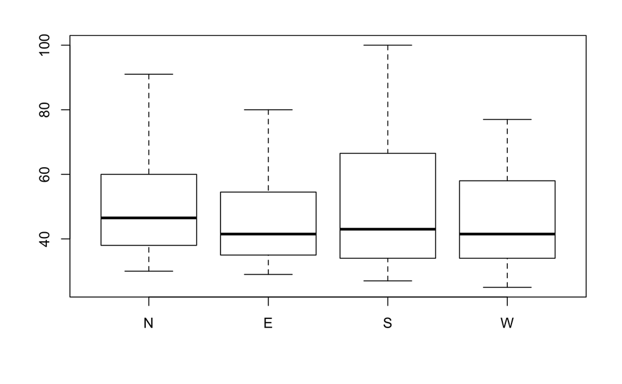

```r
boxplot(cork$N,cork$E,cork$S,cork$W, names=c("N","E","S","W"))
```

#### 변수들 모두 어느정도 치우친 것을 볼 수 있다 (근데 극단적인 것 같진 않음).

### 각 변수의 순서통계량과 정규분포 분위수 표

```r
i <- 1:n  # 순서
N.S <- sort(cork$N)  # N 순서통계량
E.S <- sort(cork$E)  # N 순서통계량
S.S <- sort(cork$S)  # N 순서통계량
W.S <- sort(cork$W)  # N 순서통계량
edf <- (i-0.5)/n  # 경험적 분포
q <- qnorm(edf, mean=0, sd=1)  # N(0,1)의 분위수

cbind(i, N.S, E.S, S.S, W.S, edf, q)
```

```
       i N.S E.S S.S W.S        edf           q
 [1,]  1  30  29  27  25 0.01785714 -2.10016549
 [2,]  2  32  29  30  25 0.05357143 -1.61116916
 [3,]  3  32  30  31  26 0.08928571 -1.34516663
 [4,]  4  32  30  31  27 0.12500000 -1.15034938
 [5,]  5  33  32  31  29 0.16071429 -0.99152647
 [6,]  6  35  34  34  31 0.19642857 -0.85444740
 [7,]  7  37  35  34  32 0.23214286 -0.73180808
 [8,]  8  39  35  34  36 0.26785714 -0.61930677
 [9,]  9  39  36  35  36 0.30357143 -0.51415610
[10,] 10  39  37  36  37 0.33928571 -0.41441333
[11,] 11  41  37  37  38 0.37500000 -0.31863936
[12,] 12  42  38  37  38 0.41071429 -0.22570795
[13,] 13  43  39  39  39 0.44642857 -0.13468979
[14,] 14  46  40  39  40 0.48214286 -0.04477618
[15,] 15  47  43  47  43 0.51785714  0.04477618
[16,] 16  48  45  48  43 0.55357143  0.13468979
[17,] 17  50  46  52  50 0.58928571  0.22570795
[18,] 18  54  50  57  50 0.62500000  0.31863936
[19,] 19  56  51  60  52 0.66071429  0.41441333
[20,] 20  56  53  64  54 0.69642857  0.51415610
[21,] 21  60  54  66  58 0.73214286  0.61930677
[22,] 22  60  55  67  58 0.76785714  0.73180808
[23,] 23  63  57  67  60 0.80357143  0.85444740
[24,] 24  72  65  68  61 0.83928571  0.99152647
[25,] 25  78  66  70  63 0.87500000  1.15034938
[26,] 26  79  68  74  63 0.91071429  1.34516663
[27,] 27  81  79  76  75 0.94642857  1.61116916
[28,] 28  91  80 100  77 0.98214286  2.10016549
```

### 각 변수의 Normal Q-Q plot

```r
layout(matrix(1:4, ncol=2))
qqnorm(N.S, pch=19, main=c("North", "Normal Q-Q plot"))  # 참고로 이때는 순서통계량으로 안써도 알아서 해주는듯
qqline(N.S, lwd=2)
```

```r
qqnorm(E.S, pch=19, main=c("East", "Normal Q-Q plot"))
qqline(E.S, lwd=2)
```

```r
qqnorm(S.S, pch=19, main=c("South", "Normal Q-Q plot"))
qqline(S.S, lwd=2)
```

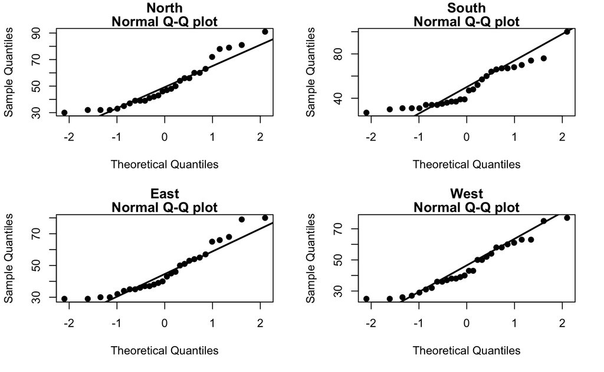

```r
qqnorm(W.S, pch=19, main=c("West", "Normal Q-Q plot"))
qqline(W.S, lwd=2)
```

#### 변수마다 직선에서 벗어난 점들이 다소 있어보인다. 근데 그렇게 많은 것 같진 않다.

### 요약:

#### 기술통계량, (줄기-잎 그림: stem()), 상자그림 등을 살펴보면 다소 오른쪽으로 꼬리가 긴 분포형태임을 알 수 있다.

#### Q-Q plot을 보면 각 변수마다 몇 개의 점들이 선형성에서 조금 벗어나나 그 정도가 크진 않다 (크게 벗어난 것들은 이상점으로 볼 수 있는지에 대한 점검이 필요).

## 다변량 정규성 진단 - Chisquare plot

### 평균벡터

```r
m <- colMeans(cork)
m
```

```
       N        E        S        W
50.53571 46.17857 49.67857 45.21429
```

### 공분산행렬

```r
S <- cov(cork)
S
```

```
         N        E        S        W
N 290.4061 223.7526 288.4378 225.5847
E 223.7526 219.9299 229.0595 170.7751
S 288.4378 229.0595 350.0040 258.9603
W 225.5847 170.7751 258.9603 224.7672
```

### 마할라노비스 거리의 순서통계량

```r
d2 <- mahalanobis(cork, m, S)
d2.S <- sort(d2)
d2.S
```

```
 [1]  1.062990  1.077703  1.364663  1.434195  1.685516  1.696628  1.729346  1.852774
 [9]  2.123196  2.236993  2.512567  2.516310  2.713061  2.834829  3.108544  3.297389
[17]  3.826041  3.923062  4.071182  4.148369  4.666397  5.418434  5.891682  7.122038
[25]  7.686233  8.565786  8.993000 10.441074
```

### 마할라노비스 거리의 순서통계량과 카이제곱분포 분위수의 표

```r
i <- 1:n  # 순서
edf <- (i-0.5)/n  # 경험적 분포
q <- qchisq(edf, p)  # 카이제곱(df=4) 분위수; p=4

cbind(i, d2.S, edf, q)
```

```
       i      d2.S        edf          q
 [1,]  1  1.062990 0.01785714  0.4040636
 [2,]  2  1.077703 0.05357143  0.7390407
 [3,]  3  1.364663 0.08928571  0.9939347
 [4,]  4  1.434195 0.12500000  1.2187621
 [5,]  5  1.685516 0.16071429  1.4281628
 [6,]  6  1.696628 0.19642857  1.6289962
 [7,]  7  1.729346 0.23214286  1.8252635
 [8,]  8  1.852774 0.26785714  2.0196591
 [9,]  9  2.123196 0.30357143  2.2142100
[10,] 10  2.236993 0.33928571  2.4105902
[11,] 11  2.512567 0.37500000  2.6102978
[12,] 12  2.516310 0.41071429  2.8147708
[13,] 13  2.713061 0.44642857  3.0254743
[14,] 14  2.834829 0.48214286  3.2439782
[15,] 15  3.108544 0.51785714  3.4720373
[16,] 16  3.297389 0.55357143  3.7116858
[17,] 17  3.826041 0.58928571  3.9653591
[18,] 18  3.923062 0.62500000  4.2360619
[19,] 19  4.071182 0.66071429  4.5276140
[20,] 20  4.148369 0.69642857  4.8450272
[21,] 21  4.666397 0.73214286  5.1951126
[22,] 22  5.418434 0.76785714  5.5875199
[23,] 23  5.891682 0.80357143  6.0366409
[24,] 24  7.122038 0.83928571  6.5654281
[25,] 25  7.686233 0.87500000  7.2140471
[26,] 26  8.565786 0.91071429  8.0633293
[27,] 27  8.993000 0.94642857  9.3203967
[28,] 28 10.441074 0.98214286 11.9329174
```

### 카이제곱(df=4)분포 그림

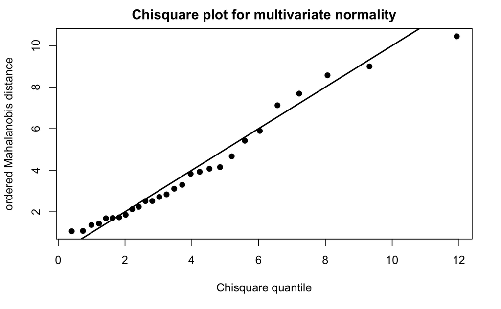

```r
plot(q, d2.S, pch=19, main="Chisquare plot for multivariate normality", xlab="Chisquare quantile", ylab="ordered Mahalanobis distance")  # 이렇게 카이제곱 그림은 산점도를 통해 그린다
abline(0,1,lwd=2)
```

#### 맨 위에 한 점을 제외하곤 마할라노비스 거리의 순서통계량과 자유도가 4인 카이제곱분포의 분위수간에 선형성이 크게 벗어나지 않음을 볼 수 있다 (크게 벗어난 점은 이상점으로 볼 수 있는지에 대한 점검이 필요).

## 다변량 정규성 진단 - 왜도와 첨도

### 공분산행렬 최우추정량(MLE)

```r
S <- cov(cork)  # 표본공분산행렬
S <- (n-1)/n*S
S
```

```
         N        E        S        W
N 280.0344 215.7615 278.1365 217.5281
E 215.7615 212.0753 220.8788 164.6760
S 278.1365 220.8788 337.5038 249.7117
W 217.5281 164.6760 249.7117 216.7398
```

### 공분산행렬 최우추정량의 역행렬

```r
solve(S)
```

```
             N           E            S           W
N  0.033220652 -0.01638359 -0.008106744 -0.01155344
E -0.016383592  0.02290085 -0.005272000  0.00511743
S -0.008106744 -0.00527200  0.027855034 -0.01995071
W -0.011553440  0.00511743 -0.019950708  0.03530688
```

### 다변량 왜도와 첨도의 추정값 구하기

```r
sk <- function(x){
  n <- dim(x)[1]  # 표본의 수
  p <- dim(x)[2]  # 변수의 수

  m <- colMeans(x)  # 평균벡터

  S <- cov(x)  # 표본공분산행렬
  S <- (n-1)/n*S  # 공분산행렬 최우추정량(MLE)
  S.inv <- solve(S)  # 공분산행렬 최우추정량의 역행렬

  g <- matrix(rep(NA,n*n), ncol=n)  # g행렬 선언
  # g행렬 구하기
  for(i in 1:n){
    for(j in 1:n){
      g[i,j] <- t(x[i,]-m) %*% S.inv %*% (x[j,]-m)
    }
  }

  b1 <- sum(g^3)/n^2  # 왜도
  b2 <- sum(diag(g)^2)/n  # 첨도

  result <- c(b1, b2)
  names(result) <- c("왜도", "첨도")
  return(result)
}
```

#### g행렬 구할 때 행렬연산이 있으므로 데이터를 행렬로 변환시키고 구하자

```r
mat <- as.matrix(cork)  # 데이터 타입을 matrix로

sk(mat)
```

```
     왜도      첨도
 4.525909 23.013260
```

### 가설

#### H0: 정규성이 성립한다 (왜도 = 0 and 첨도 = p(p+2); 둘다 만족되어야 함)

#### H1: 정규성이 성립하지 않는다

#### n=28 (근데 표에 28이 없어서 30을 사용), p=4, 유의수준 0.05이므로 왜도의 기각값이 5.6, 첨도의 기각값이 25.5이다. 따라서 왜도와 첨도 모두 기각값보다 작으므로 귀무가설을 채택한다. 즉, 해당 변수들은 다변량 정규분포를 따른다고 할 수 있다.